# Is there a heat island generated by Eugene, Oregon?

## A Bootstrapped Estimate of Differences in Temperatures Between Eugene and its surroundings

Damian Satterthwaite - Phillips

## Introduction

There are analytical methods for handling the temporal and spatial autocorrelation in data sets like this one, but specifying a model that fits the data well without making potentially spurious assumptions about the structure of the data can be challenging.

Another more “brute force” approach is to create bootstrapped estimates from the existing data. This approach relies on randomly resampling the data many times to effectively simulate what temperatures may be expected under different conditions.

In this case, the variables, elevation, and precipitation are converted to categorical variables: elevation - low/medium/high, and precipitation - none/low/medium/high, and we already a categorical variable 'adjWater', indicating if a location is adjacent to a river or lake. Each locus is further labeled as 'city', for points near the center of the cities (Eugene or Springfield) 'periph', if they are around the edge of the city, and 'rural', if farther away. For each date and set of conditions, we randomly sample temperatures from all loci that meet those conditions, and generate an expected value. We then look at the differences in city and rural values when all other conditions are held constant, and perform statistical analyses on these differences.

## Set up

A heat map visualization of the data can be seen [here](http://phillips-research.com/uhi/app/interactiveMap.html).

```r
# Clear R memory, and load necessary libraries
rm(list = ls())
library(lattice)

# Warnings are turned off here so that they will not appear in the final
# knitted html file.  Omit this line when running locally.
options(warn = -1)
```

```r
# Load in the data (change the path as needed)
eug = read.csv('~/Desktop/PRA/uhi/dataComplied/eug2014.csv')

eug$ID = as.factor(eug$ID)
eug$date = as.Date(eug$date)
alpha = 0.01

# Store the number of rows in the data
r = dim(eug)[1]
```

The next bit of code assigns each locus to city, periph, or rural (this was done simply by eyeballing their locations on Google maps [here](http://phillips-research.com/uhi/map.html)). Recall that numbering begins at the lower left, with the westernmost column of loci being 1 - 10, the next column to the right 11 - 20, and so forth.

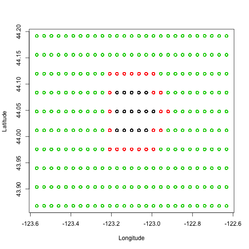

```r
# Subdivide the data into categories:
city = c(115:117, 125:127, 135:137, 145:147, 155:157, 166)
periph = c( 104:108, 114, 118, 124, 128, 134, 138, 144, 148, 154, 158, 164,
            165, 167, 168, 175:177, 186 )
rural = 1:270[-c(city, periph)]

# Create the vector as a column in the eug data frame
distCat = rep('rural', r)
distCat[which(eug$ID %in% city)] = 'city'
distCat[which(eug$ID %in% periph)] = 'periph'
eug$distCat = factor(distCat, levels = c('city', 'periph', 'rural'))
rm(distCat, city, periph, rural)

# Plot to make sure it looks ok
plot(eug$x, eug$y, col = eug$distCat, xlab = 'Longitude', ylab = 'Latitude')
```

When dividing the numerical variables into categories, we want to do it in such a way that divides the values as evenly as possible, so we maximize the amount of data points in each subset. For precipitation:

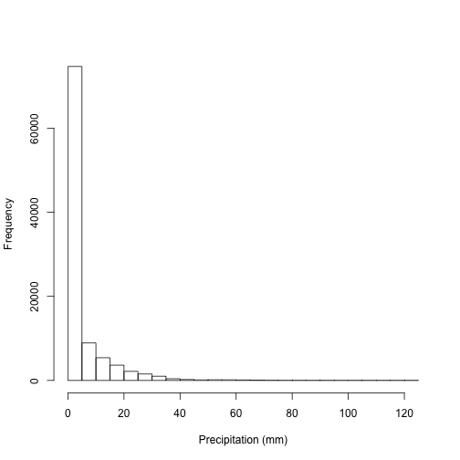

```r
# First find good divisions
hist(eug$ppt, main = '', xlab = 'Precipitation (mm)')
```

```r
# 0 is one good candidate, since data points with 0 ppt are the most common
# And looking at just data with ppt:
hist( eug$ppt[eug$ppt > 0], main = 'Data with rain only',
      xlab = 'Precipitation (mm)' )
(pptMed = median(eug$ppt[eug$ppt > 0]))
```

```
## [1] 4.33
```

```r
(ppt3 = quantile(eug$ppt[eug$ppt > 0], prob = c(0.333, 0.667)))
```

```
## 33.3% 66.7%
##  2.00  8.52
```

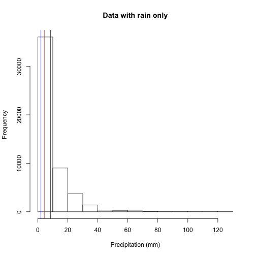

```r
abline(v = pptMed, col = 2)
abline(v = ppt3, col = 4)
```

```r
# Divide the data into 4 groups spliting at 0, 2.00, and 8.52 mm. Save in
# 'ppt4 and attach to eug data frame
ppt4 = factor(rep('none', r), levels = c('none', 'low', 'med', 'high'))

ppt4[which(eug$ppt > 0)] = 'low'
ppt4[which(eug$ppt > 2.00)] = 'med'
ppt4[which(eug$ppt > 8.52)] = 'high'
table(ppt4)
```

```
## ppt4
##  none   low   med  high
## 47541 16996 17025 16988
```

```r
eug$ppt4 = ppt4
rm(ppt4)
```

Glance at some of the relationships

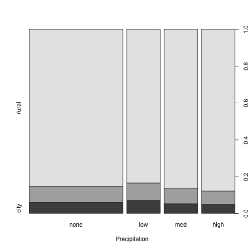

```r
plot(eug$distCat ~ eug$ppt4, xlab = 'Precipitation', ylab = '')
```

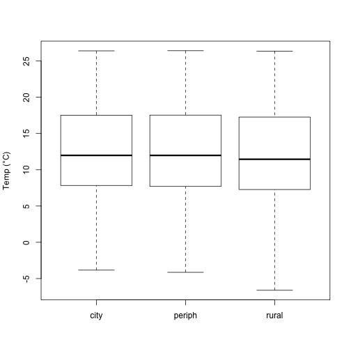

```r
plot(eug$temp ~ eug$distCat , xlab = '', ylab = 'Temp (°C)')
```

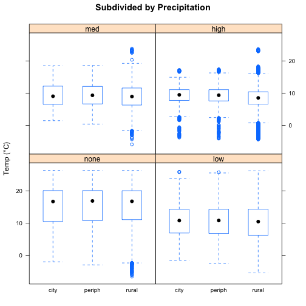

```r
bwplot( eug$temp ~ eug$distCat | eug$ppt4, ylab = 'Temp (°C)',
        main = 'Subdivided by Precipitation' )
```

At this point, there are no obvious differences in city vs. rural temperatures.

Do the same with elevation:

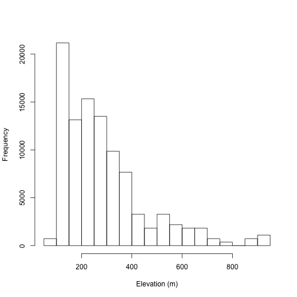

```r
hist(eug$elev, main = '', xlab = 'Elevation (m)')
```

```r
(cityElev3 = quantile( eug$elev[eug$distCat == 'city'],
                       prob =c(0.333, 0.667) ))
```

```
## 33.3% 66.7%
## 128.5 143.2
```

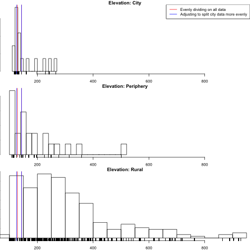

```r
# We can't just split evenly, because there are different elevation dstributions within the city and the surroundings.  By adjusting the divisions slightly, we can divide the urban data more evenly.
cityElevAdj = c(126, 143.2) # instead of the 128.5, 143.2 given above
par(mfrow = c(3, 1))
par(mar = c(2, 0, 1, 0))
hist( eug$elev[eug$distCat == 'city'], xlim = range(eug$elev),
      main = 'Elevation: City' )
abline(v = cityElev3, col = 2)
abline(v = cityElevAdj, col = 4)
rug(eug$elev[eug$distCat == 'city'])
legend( 'topright', lty = 1, col = c(2, 4),
        legend = c( 'Evenly dividing on all data',
                    'Adjusting to split city data more evenly '))

hist( eug$elev[eug$distCat == 'periph'], xlim = range(eug$elev),
      main = 'Elevation: Periphery')
abline(v = cityElev3, col = 2)
abline(v = cityElevAdj, col = 4)
rug(eug$elev[eug$distCat == 'periph'])

hist( eug$elev[eug$distCat == 'rural'], xlim = range(eug$elev),
      main = 'Elevation: Rural')
abline(v = cityElev3, col = 2)
abline(v = cityElevAdj, col = 4)
rug(eug$elev[eug$distCat == 'rural'])
```

```r
elev3 = factor(rep('high', r), level = c('low', 'med', 'high'))
elev3[which(eug$elev < 143.2)] = 'med'
elev3[which(eug$elev < 126)] = 'low'
eug$elev3 = elev3

table(eug$elev3, eug$distCat)
```

```
##
##         city periph rural
##   low   1825   2190  9125
##   med   1825   1095  3285
##   high  2190   5110 71905
```

```r
rm(elev3)
```

And, glimpse at some of these relationships.

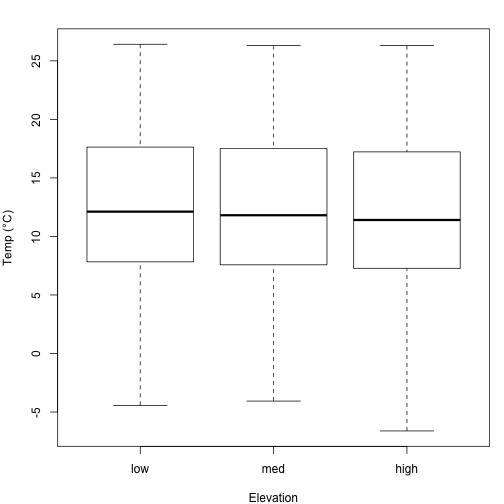

```r
par(mfrow = c(1, 1))
par(mar = c(4, 4, 2, 1))
plot(eug$temp ~ eug$elev3, xlab = 'Elevation', ylab = 'Temp (°C)')
```

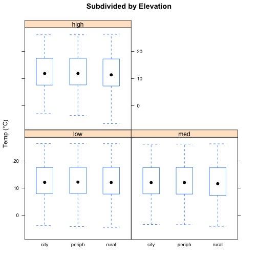

```r
bwplot( eug$temp ~ eug$distCat | eug$elev3, ylab = 'Temp (°C)',
        main = 'Subdivided by Elevation' )
```

Again no readily discernible differences in temperatures.

## Possible subsets of the data

We now have the following categorical variables with the following values:

- Adjacent to Water - adjWater (TRUE, FALSE)
- Precipitation -ppt4 (none: 0 mm, low ≤ 2.00 mm > med ≤ 8.52 mm < high)
- Elevation - elev3 (low ≤ 126 m < med ≤ 143.2m < high)
- And a distance from city category - distCat (city, periph, or rural)

All in all this makes for 2 * 4 * 3 * 3 = 72 unique subsets of the data, such as: {adjW = T, ppt4 = 'none', elev3 = 'low', and distCat = 'city'} or {adjW = F, ppt4 = 'low', elev3 = 'med', and distCat = 'rural'}, and so on. As a shorthand, each unique subset will be given a four letter code depending on the value of each parameter. E.g., tnlc for first example (True-none-low-city), and flmr for the second (False-low-medium-rural). These will be ordered as: adjWater-ppt4-elev3-distCat, with possible values as: {tf}{nlmh}{lmh}{cpr}

Generate all possible combinations as shorthand abbreviations:

```r
subnames = c()
for (water in c('t', 'f')) {
    for (precip in c('n', 'l', 'm', 'h')) {
        for (elev in c('l', 'm', 'h')) {
            for (dist in c('c', 'p', 'r')) {
                subnames = c( subnames,
                              paste(water, precip, elev, dist, sep = '') )
            }
        }
    }
}

# Check
subnames
```

```
##  [1] "tnlc" "tnlp" "tnlr" "tnmc" "tnmp" "tnmr" "tnhc" "tnhp" "tnhr" "tllc"
## [11] "tllp" "tllr" "tlmc" "tlmp" "tlmr" "tlhc" "tlhp" "tlhr" "tmlc" "tmlp"
## [21] "tmlr" "tmmc" "tmmp" "tmmr" "tmhc" "tmhp" "tmhr" "thlc" "thlp" "thlr"
## [31] "thmc" "thmp" "thmr" "thhc" "thhp" "thhr" "fnlc" "fnlp" "fnlr" "fnmc"
## [41] "fnmp" "fnmr" "fnhc" "fnhp" "fnhr" "fllc" "fllp" "fllr" "flmc" "flmp"
## [51] "flmr" "flhc" "flhp" "flhr" "fmlc" "fmlp" "fmlr" "fmmc" "fmmp" "fmmr"
## [61] "fmhc" "fmhp" "fmhr" "fhlc" "fhlp" "fhlr" "fhmc" "fhmp" "fhmr" "fhhc"
## [71] "fhhp" "fhhr"
```

Next generate each unique subset as a data.frame, and save it to a list.

```r
subset.list = list()

i = 1
for(water in c(T, F)) {
    for (precip in c('none', 'low', 'med', 'high')) {
        for (el in c('low', 'med', 'high')) {
            for (dist in c('city', 'periph', 'rural')) {

                subset.list[[subnames[i]]] =
                                    subset( eug, adjWater == water &
                                            ppt4 == precip &
                                            elev3 == el &
                                            distCat == dist )
                i = i + 1
            }
        }
    }
}

# Check to make sure this worked as planned
length(subset.list)
```

```
## [1] 72
```

```r
str(subset.list[['tnlc']])
```

```
## 'data.frame':    544 obs. of  24 variables:
##  $ X          : int  45626 45629 45630 45639 45640 45641 45642 45643 45644 45646 ...
##  $ date       : Date, format: "2014-01-01" "2014-01-04" ...
##  $ ppt        : num  0 0 0 0 0 0 0 0 0 0 ...
##  $ tmin       : num  -0.05 -1.87 -3.36 1.06 1.24 ...
##  $ tmax       : num  10.8 8.73 3.81 11.51 7.09 ...
##  $ x          : num  -123 -123 -123 -123 -123 ...
##  $ y          : num  44 44 44 44 44 ...
##  $ station    : Factor w/ 270 levels "(-122.6327, 43.8677)",..: 146 146 146 146 146 146 146 146 146 146 ...
##  $ ID         : Factor w/ 270 levels "1","2","3","4",..: 126 126 126 126 126 126 126 126 126 126 ...
##  $ elev       : num  124 124 124 124 124 124 124 124 124 124 ...
##  $ adjWater   : logi  TRUE TRUE TRUE TRUE TRUE TRUE ...
##  $ distCC     : num  2.13 2.13 2.13 2.13 2.13 ...
##  $ tminDiff   : num  NA -3.06 -1.49 -4.11 0.18 ...
##  $ tmaxDiff   : num  NA -1.38 -4.92 1.14 -4.42 ...
##  $ temp       : num  5.375 3.43 0.225 6.285 4.165 ...
##  $ tempDiff   : num  NA -2.22 -3.2 -1.48 -2.12 ...
##  $ pptT       : num  0 0 0 0 0 0 0 0 0 0 ...
##  $ elevT      : num  0.441 0.441 0.441 0.441 0.441 ...
##  $ inCity     : logi  TRUE TRUE TRUE TRUE TRUE TRUE ...
##  $ areaMedTemp: num  5.952 3.328 0.715 6.13 5.065 ...
##  $ tempIrreg  : num  -0.577 0.102 -0.49 0.155 -0.9 ...
##  $ distCat    : Factor w/ 3 levels "city","periph",..: 1 1 1 1 1 1 1 1 1 1 ...
##  $ ppt4       : Factor w/ 4 levels "none","low","med",..: 1 1 1 1 1 1 1 1 1 1 ...
##  $ elev3      : Factor w/ 3 levels "low","med","high": 1 1 1 1 1 1 1 1 1 1 ...
```

```r
# looks good!
```

Next, lets visualize the data in each of the subsets.

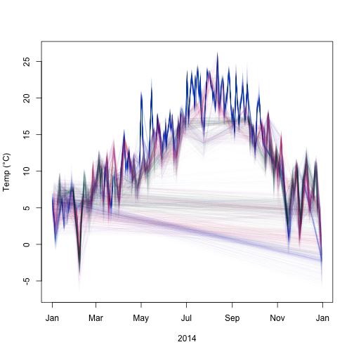

```r
# A helper function to generate a random color:
rcolor = function(alpha = 1) {
    r = runif(1)
    g = runif(1)
    b = runif(1, 0:(2 - r - g)) # keep it from being too close to white
    rgb(r, g, b, alpha)
}


plot(eug$temp ~ eug$date, type = 'n', xlab = '2014', ylab = 'Temp (°C)')
for (l in subset.list) {
    lines(l$temp ~ l$date, col = rcolor(alpha = 0.02))
}
```

Evidentally, some subsets have many missing data points, but we will make do with what we have. To see our data numbers better:

```r
# Number of rows in each subset:
unlist(lapply(subset.list, nrow))
```

```
##  tnlc  tnlp  tnlr  tnmc  tnmp  tnmr  tnhc  tnhp  tnhr  tllc  tllp  tllr
##   544   546  2415   920   189   331   365   888  7113   227   215  1088
##  tlmc  tlmp  tlmr  tlhc  tlhp  tlhr  tmlc  tmlp  tmlr  tmmc  tmmp  tmmr
##   370    68   170   150   346  2183   170   181   878   271    58   125
##  tmhc  tmhp  tmhr  thlc  thlp  thlr  thmc  thmp  thmr  thhc  thhp  thhr
##   113   303  2237   154   153   729   264    50   104   102   288  2702
##  fnlc  fnlp  fnlr  fnmc  fnmp  fnmr  fnhc  fnhp  fnhr  fllc  fllp  fllr
##   363   529  1886     0   365  1213   724  1596 27554   147   218   847
##  flmc  flmp  flmr  flhc  flhp  flhr  fmlc  fmlp  fmlr  fmmc  fmmp  fmmr
##     0   142   463   299   640  9423   116   188   705     0   119   466
##  fmhc  fmhp  fmhr  fhlc  fhlp  fhlr  fhmc  fhmp  fhmr  fhhc  fhhp  fhhr
##   233   556 10306   104   160   577     0   104   413   204   493 10387
```

```r
# Number of dates for which each subset has data
unlist(lapply(subset.list, function(x) length(unique(x$date))))
```

```
## tnlc tnlp tnlr tnmc tnmp tnmr tnhc tnhp tnhr tllc tllp tllr tlmc tlmp tlmr
##  190  184  200  193  189  181  191  188  205   94   80  138   97   68  110
## tlhc tlhp tlhr tmlc tmlp tmlr tmmc tmmp tmmr tmhc tmhp tmhr thlc thlp thlr
##   89   92  113   72   70  114   68   58   82   64   75  114   56   55   73
## thmc thmp thmr thhc thhp thhr fnlc fnlp fnlr fnmc fnmp fnmr fnhc fnhp fnhr
##   58   50   62   53   65  110  189  182  194    0  191  197  190  202  216
## fllc fllp fllr flmc flmp flmr flhc flhp flhr fmlc fmlp fmlr fmmc fmmp fmmr
##   87   85  118    0   87  120   91  110  168   66   69   98    0   71  113
## fmhc fmhp fmhr fhlc fhlp fhlr fhmc fhmp fhmr fhhc fhhp fhhr
##   66   97  153   54   56   68    0   56   84   55   77  130
```

```r
# Not ideal, but workable...
```

## Analysis - An example

Now what we want to do is the following. For each subset randomly sample the temperature at each day, and plot the raw data, median, and 95% CI. For example, using the largest subset:

```r
sort(unlist(lapply(subset.list, function(x) length(unique(x$date)))))
```

```
## fnmc flmc fmmc fhmc thmp thhc fhlc thlp fhhc thlc fhlp fhmp tmmp thmc thmr
##    0    0    0    0   50   53   54   55   55   56   56   56   58   58   62
## tmhc thhp fmlc fmhc tlmp tmmc fhlr fmlp tmlp fmmp tmlc thlr tmhp fhhp tllp
##   64   65   66   66   68   68   68   69   70   71   72   73   75   77   80
## tmmr fhmr fllp fllc flmp tlhc flhc tlhp tllc tlmc fmhp fmlr tlmr thhr flhp
##   82   84   85   87   87   89   91   92   94   97   97   98  110  110  110
## tlhr fmmr tmlr tmhr fllr flmr fhhr tllr fmhr flhr tnmr fnlp tnlp tnhp tnmp
##  113  113  114  114  118  120  130  138  153  168  181  182  184  188  189
## fnlc tnlc fnhc tnhc fnmp tnmc fnlr fnmr tnlr fnhp tnhr fnhr
##  189  190  190  191  191  193  194  197  200  202  205  216
```

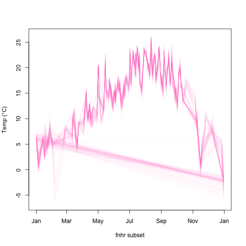

```r
# fnhr has the most data--look at just that subset
plot( subset.list$fnhr$temp ~ subset.list$fnhr$date, type = 'l',
      col = rcolor(0.05), ylab = 'Temp (°C)', xlab = 'fnhr subset')
```

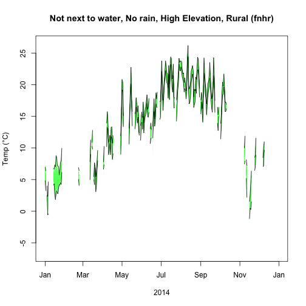

```r
# Now, taking 1000 random samplings at each date (with replacement!):
samps = 1000
dates = sort(unique(eug$date))
outM = matrix(nrow = length(dates), ncol = samps + 1)
outM[, 1] = as.Date(dates)

for(d in 1:length(dates)) {
    if (dates[d] %in% subset.list$fnhr$date) {
        outM[d, 2:(samps + 1)] =
            sample( subset.list$fnhr$temp[ subset.list$fnhr$date == dates[d] ],
                    samps, replace = T )
    }
}

plot( eug$temp ~ eug$date, type = 'n',
      main = 'Not next to water, No rain, High Elevation, Rural (fnhr)',
      xlab = '2014', ylab = 'Temp (°C)')
color1 = rcolor(alpha = 10 / samps)
for (s in 2:(samps + 1)) {
    lines(outM[, s] ~ outM[, 1], col = color1 )
}

# We can then calculate the expected (median) value and middle 95% from the
# sampled data:
ci1 = apply(outM[, -1], 1, quantile, probs = c(0.025, 0.5, 0.975), na.rm = T)
lines(ci1[1, ] ~ outM[, 1])
lines(ci1[3, ] ~ outM[, 1])
```

Now contrast this with the subset with the same values except in the city (fnhc):

```r
outM = matrix(nrow = length(dates), ncol = samps + 1)
outM[, 1] = dates

for(d in 1:length(dates)) {
    if (dates[d] %in% subset.list$fnhc$date) {
        # it turns out that the sample function acts unusally if sampling a
        # vector, x, of length 1: it treats sample(x) as sample(1:xL), so, a
        # little extra code here to simply repeat the value if there is only
        # one.
        # see ?sample
        if (length(subset.list$fnhc$temp[ subset.list$fnhc$date == dates[d] ]) > 1) {
            outM[d, 2:(samps + 1)] =
                sample( subset.list$fnhc$temp[ subset.list$fnhc$date == dates[d] ],
                        samps, replace = T )
        } else {
            outM[d, 2:(samps + 1)] =
                rep(subset.list$fnhc$temp[ subset.list$fnhc$date == dates[d] ], samps )
        }
    }
}

# Additions to plots cannot be done through knitr, but will run locally.
# color2 = rcolor(alpha = 10 / samps)
# for (s in 2:(samps + 1)) {
#   lines(outM[, s] ~ outM[,1], col = color2 )
# }

ci2 = apply(outM[, -1], 1, quantile, probs = c(0.025, 0.5, 0.975), na.rm = T)
# Additions to plots cannot be done through knitr, but will run locally.
# lines(ci2[1, ] ~ outM[, 1], col = 2)
# lines(ci2[3, ] ~ outM[, 1], col = 2)
```

And to make the visualization clearer, plot just the CIs, and zoom in.

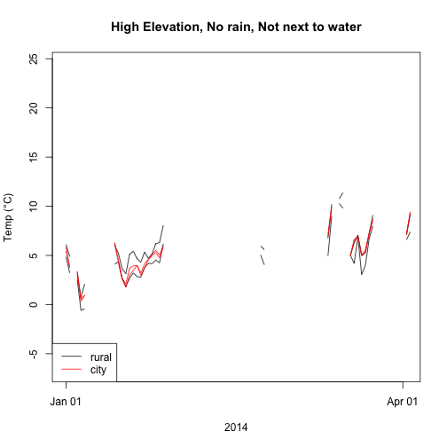

```r
seasLim = seq(min(eug$date), max(eug$date), length = 5)
mainTitle = 'High Elevation, No rain, Not next to water'
# Set 'origin' to calibrate dates
o = '1970-01-01'

plot( ci1[1, ] ~ as.Date(outM[, 1], origin = o), type = 'l',
      xlim = c(seasLim[1], seasLim[2]), main = mainTitle, xlab = '2014',
      ylab = 'Temp (°C)')
lines(ci1[2, ] ~ as.Date(outM[, 1], origin = o))
lines(ci2[1, ] ~ as.Date(outM[, 1], origin = o), col = 2)
lines(ci2[2, ] ~ as.Date(outM[, 1], origin = o), col = 2)
legend('bottomleft', lty = 1, col = 1:2, legend = c('rural', 'city'))
```

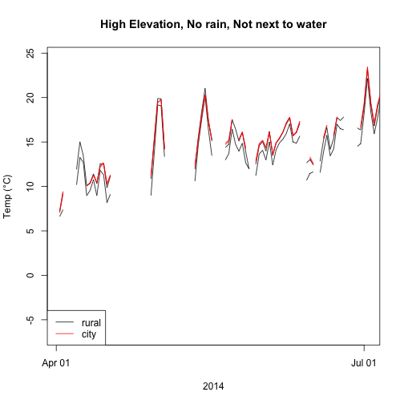

```r
plot( ci1[1, ] ~ as.Date(outM[, 1], origin = o), type = 'l',
      xlim = c(seasLim[2], seasLim[3]), main = mainTitle, xlab = '2014',
      ylab = 'Temp (°C)' )
lines(ci1[2, ] ~ as.Date(outM[, 1], origin = o))
lines(ci2[1, ] ~ as.Date(outM[, 1], origin = o), col = 2)
lines(ci2[2, ] ~ as.Date(outM[, 1], origin = o), col = 2)
legend('bottomleft', lty = 1, col = 1:2, legend = c('rural', 'city'))
```

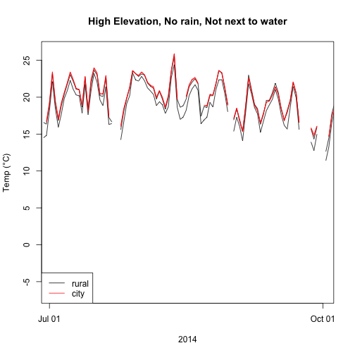

```r
plot( ci1[1, ] ~ as.Date(outM[, 1], origin = o), type = 'l',
      xlim = c(seasLim[3], seasLim[4]),
      ylim = range(c(ci1, ci2), na.rm = T), main = mainTitle, xlab = '2014',
      ylab = 'Temp (°C)' )
lines(ci1[2, ] ~ as.Date(outM[, 1], origin = o))
lines(ci2[1, ] ~ as.Date(outM[, 1], origin = o), col = 2)
lines(ci2[2, ] ~ as.Date(outM[, 1], origin = o), col = 2)
legend('bottomleft', lty = 1, col = 1:2, legend = c('rural', 'city'))
```

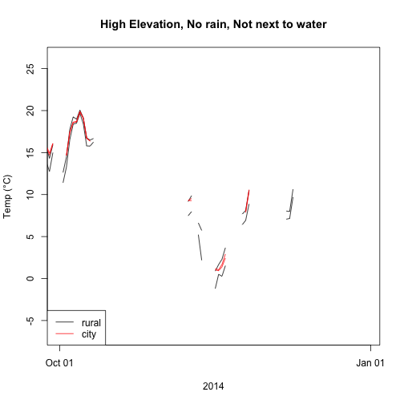

```r
plot( ci1[1, ] ~ as.Date(outM[, 1], origin = o), type = 'l',
      xlim = c(seasLim[4], seasLim[5]),
      ylim = range(c(ci1, ci2), na.rm = T), main = mainTitle, xlab = '2014',
      ylab = 'Temp (°C)' )
lines(ci1[2, ] ~ as.Date(outM[, 1], origin = o))
lines(ci2[1, ] ~ as.Date(outM[, 1], origin = o), col = 2)
lines(ci2[2, ] ~ as.Date(outM[, 1], origin = o), col = 2)
legend('bottomleft', lty = 1, col = 1:2, legend = c('rural', 'city'))
```

## Interpreting the Results

What we see here is that, for many of the dates, the 95% CIs for the city are above those for the surrounding areas, suggesting warmer city temperatures. In other cases the CIs are overlapping suggesting no significant difference on those dates.

However, there are also some caveats. These figures are based on the extant data, which are few for any given date, so the inference is only as good as the diversity of the data. To increase our statistical power, we could calculate the the difference of the median estimate for each day, and then determine if this is significantly different from the null hypothesis: that the temperatures are the same, and hence the difference = 0. (Note that ci1 and ci2 contain the median values as well as the 95 percent CI limits.)

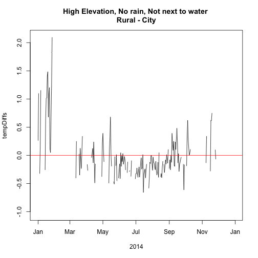

```r
tempDiffs = ci1[2, ] - ci2[2, ] # NOTE: this is rural - city
plot( tempDiffs ~ as.Date(outM[, 1], origin = o), type = 'l', xlab = '2014',
      main = paste(mainTitle, '\nRural - City') )
abline(h = 0, col = 2)
```

Something to notice here, is that for the winter months the values are mostly postive (rural is hotter), and for summer, mostly negative (city is hotter).

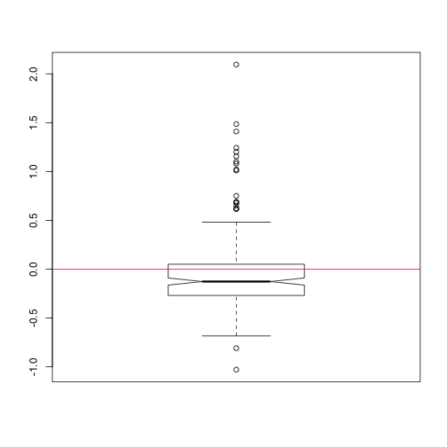

```r
boxplot(tempDiffs, notch = T)
abline(h = 0, col = 2)
```

The notch in the box shows the approximate 95% CI for the median, and it is fully below the null hypothesis line (red), indicating that over the course of the whole year, the difference is negative, i.e., the city is warmer, than the surrounding rural area (for high elevation, on dry days, and loci not adjacent to rivers or lakes).

```r
wilcox.test(tempDiffs)
```

```
##
##  Wilcoxon signed rank test with continuity correction
##
## data:  tempDiffs
## V = 6068.5, p-value = 7.586e-05
## alternative hypothesis: true location is not equal to 0
```

…and we see that the median value is significantly lower than 0 (p << 0.001)

For those of you who are more comfortable or familiar with the t.test, you may be tempted by:

```r
t.test(tempDiffs)
```

```
##
##  One Sample t-test
##
## data:  tempDiffs
## t = -1.177, df = 189, p-value = 0.2407
## alternative hypothesis: true mean is not equal to 0
## 95 percent confidence interval:
##  -0.09700411  0.02450417
## sample estimates:
##   mean of x
## -0.03624997
```

…but this is problematic as the data are not normally distributed:

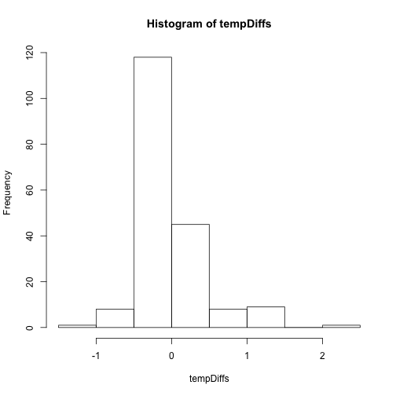

```r
hist(tempDiffs)
```

```r
shapiro.test(tempDiffs)
```

```
##
##  Shapiro-Wilk normality test
##
## data:  tempDiffs
## W = 0.8447, p-value = 5.806e-13
```

…which violates the assumptions of the t-test, as extreme values effect the mean considerably more than they do the median. To exemplify, the means and medians are plotted with and without the 2 most extreme values.

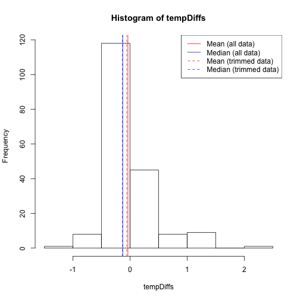

```r
hist(tempDiffs)
abline(v = mean(tempDiffs, na.rm = T), col = 2)
abline(v = median(tempDiffs, na.rm = T), col = 4)
# Plot mean and median again with most extreme 2 values removed:
abline( v = mean(sort(tempDiffs, decreasing = T)[-c(1:2)], na.rm = T),
        col = 2, lty = 2 )
abline( v = median(sort(tempDiffs, decreasing = T)[-c(1:2)], na.rm = T),
        col = 4, lty = 2 )
legend( 'topright', lty = c(1, 1, 2, 2), col = c(2, 4),
        legend = c( 'Mean (all data)', 'Median (all data)',
                    'Mean (trimmed data)', 'Median (trimmed data)'))
```

Finally, because we noted that the relationship of the temperatures seemed to reverse depending on whether we were looking at summer or winter data, let's explore these separately.

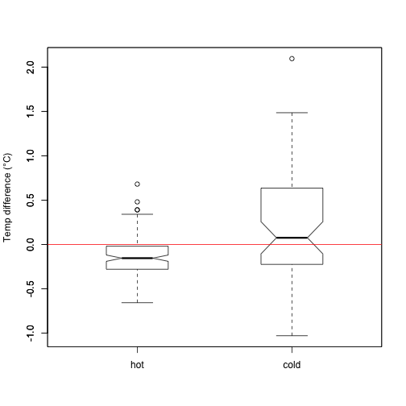

```r
equinoxes = as.Date(c('2014-03-20', '2014-09-22'))
seas = rep('cold', 365)
seas[outM[, 1] > equinoxes[1] & outM[, 1] <= equinoxes[2]] = 'hot'

hotDiffs = tempDiffs[seas == 'hot']
coldDiffs = tempDiffs[seas == 'cold']

boxplot( hotDiffs, xlim = c(0.5, 2.5), notch = T,
         ylim = range(tempDiffs, na.rm = T), ylab = 'Temp difference (°C)')
boxplot(coldDiffs, at = 2, add = T, notch = T)
axis(1, at = c(1, 2), labels = c('hot', 'cold'))
abline(h = 0, col = 2)
```

As suspected, the city is hotter in the warm months, but cooler in the cold months (though the latter is not significant):

```r
wilcox.test(hotDiffs)
```

```
##
##  Wilcoxon signed rank test with continuity correction
##
## data:  hotDiffs
## V = 1585.5, p-value = 6.965e-11
## alternative hypothesis: true location is not equal to 0
```

```r
wilcox.test(coldDiffs)
```

```
##
##  Wilcoxon signed rank test with continuity correction
##
## data:  coldDiffs
## V = 1014, p-value = 0.07877
## alternative hypothesis: true location is not equal to 0
```

```r
median(tempDiffs, na.rm = T)
```

```
## [1] -0.1275005
```

```r
median(hotDiffs, na.rm = T)
```

```
## [1] -0.155
```

```r
median(coldDiffs, na.rm = T)
```

```
## [1] 0.07500014
```

To examine these, let's first automate the previous analysis to speed things up.